# Assignment 7

Dea Karam

2026-04-19

## Import required packages

```r
suppressPackageStartupMessages({
  library(epiwraps)
  library(AnnotationHub)
  library(MotifDb)
  library(motifmatchr)
  library(universalmotif)
  library(ensembldb)
  library(GenomicRanges)
  library(Rsamtools)
  library(rtracklayer)
  library(ggplot2)
  library(BSgenome.Mmusculus.UCSC.mm10)
  library(TFBSTools)
  library(sechm)
  library(limma)
  library(betterChromVAR)
  library(ggrepel)
})
```

```
## See system.file("LICENSE", package="MotifDb") for use restrictions.
```

# Part 1: Insertion and nucleosome-center profiles around NRF1 motifs on chr19

For this analysis, I chose NRF1 (Nuclear Respiratory Factor 1), a transcription factor that regulates nuclear-encoded mitochondrial genes through a short GC-rich palindromic motif and is active in essentially all tissues.

## Download the data

```r
download.file("https://ethz-ins.org/content/w7/atac.chr19.bam", "atac.chr19.bam", mode="wb")
download.file("https://ethz-ins.org/content/w7/atac.chr19.bam.bai", "atac.chr19.bam.bai", mode="wb")
```

## Preparing the tracks

From the paired-end ATAC BAM I generate two bigwig tracks:

1. **`NF_cuts.bw`**: the number of Tn5 insertion sites (cuts, i.e. fragment ends) at each position, using only nucleosome-free fragments (30–120 bp).
2. **`mono_centers.bw`**: the centers of mono-nucleosome fragments (140–220 bp), which indicates where nucleosomes are positioned.

```r
bam <- "atac.chr19.bam"

bam2bw(bam, output_bw = "NF_cuts.bw", paired=TRUE, binWidth=1L, type="ends",
       minFragLength=30, maxFragLength=120, trim=4L, extend=3L,
       forceSeqlevelsStyle = "Ensembl")
```

```
## Reading in signal...
```

```
## Writing bigwig...
```

```r
bam2bw(bam, output_bw = "mono_centers.bw", paired = TRUE, binWidth = 5L, type = "center",
       minFragLength = 140, maxFragLength = 220, trim = 4L, extend = 10L,
       forceSeqlevelsStyle = "Ensembl")
```

```
## Reading in signal...
## Writing bigwig...
```

## Getting high-confidence NRF1 motif occurrences on chr19

I fetch the mouse NRF1 motif from `MotifDb`, convert it to a `TFBSTools` PFMatrix, and scan chr19 for matches using a stringent p-value cutoff (`1e-5`) so that the remaining hits are high-confidence.

```r
ah <- AnnotationHub()
genome <- ah[["AH68356"]]
```

```
## loading from cache
```

```r
chr19  <- import(genome)["19"]

motif <- MotifDb::query(MotifDb, c("NRF1", "Mmusculus"))[[1]]
motif2 <- convert_motifs(motif, class="TFBSTools-PFMatrix")
```

```
## Note: motif [motif] has an empty nsites slot, using 100.
```

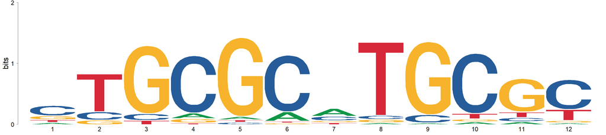

```r
view_motifs(motif)
```

```r
moi <- motifmatchr::matchMotifs(motif2, chr19, out="positions", p.cutoff=1e-5)[[1]]
moi <- as(setNames(moi, names(chr19)), "GRanges")
length(moi)
```

```
## [1] 1363
```

## Plotting the two signals around NRF1 motif occurrences

I extract both signals in 300-bp windows around each motif match (5-bp bins) and plot them as an enriched heatmap side by side. Below the heatmap, I also overlay the aggregated profiles.

```r
tracks <- c(NF_cuts = "NF_cuts.bw", mono_centers = "mono_centers.bw")

sm <- signal2Matrix(tracks, moi, w=5, extend=300)
```

```
## Reading NF_cuts.bw
```

```
## Reading mono_centers.bw
```

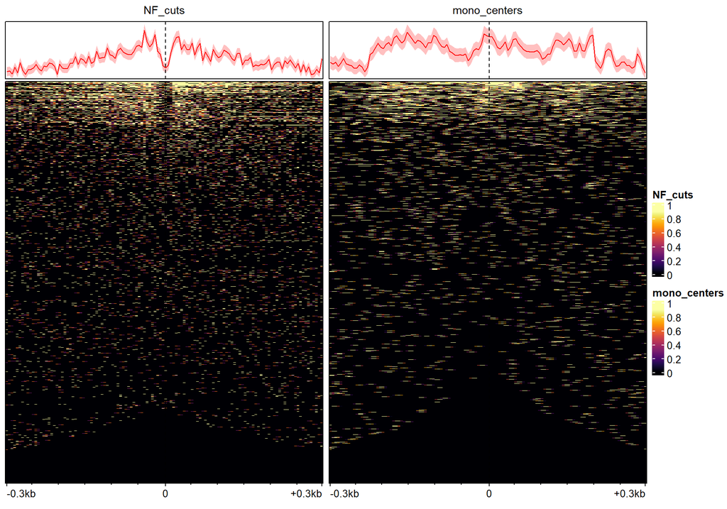

```r
plotEnrichedHeatmaps(sm, trim=0.95, multiScale = TRUE, axis_name = "0")
```

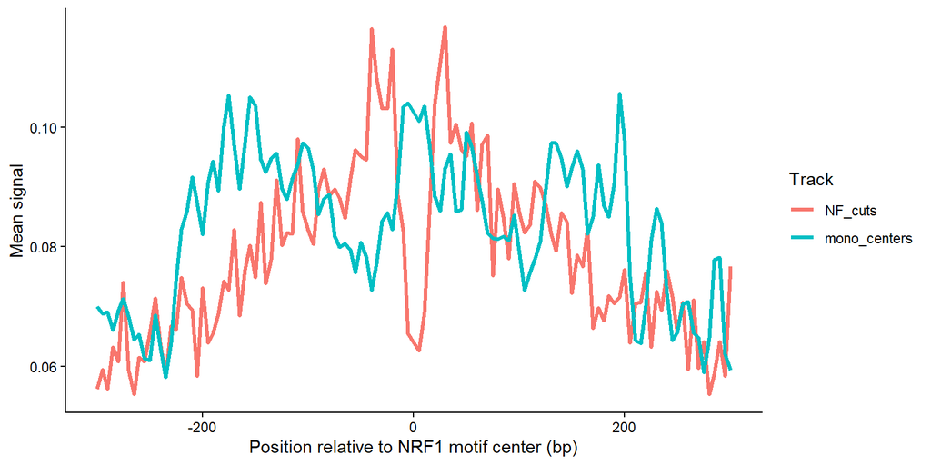

```r
d <- meltSignals(sm)
ggplot(d, aes(position, mean, colour=sample)) +
  geom_line(linewidth=1.2) +
  labs(x = "Position relative to NRF1 motif center (bp)",
       y = "Mean signal",
       colour = "Track") +
  theme_classic()
```

# Part 2: Motifs changing in accessibility between males and females

For this part of the assignment, I re-use the ATAC-seq dataset from week 5.

## Downloading the Data

```r
download.file("https://ethz-ins.org/content/mouse_mm38_hippocampus.peakCounts.SE.rds", "peakCounts.rds", mode="wb")
```

```r
se <- readRDS("peakCounts.rds")
```

I restrict to standard chromosomes, align the seqlevels style with the `BSgenome` object and add the GC bias (needed by betterChromVAR)

```r
se <- GenomeInfoDb::keepStandardChromosomes(se, pruning.mode = "coarse")
seqlevelsStyle(se) <- "UCSC"
se <- addGCBias(se, genome=BSgenome.Mmusculus.UCSC.mm10)
```

## Finding motif matches

I use the non-redundant HOCOMOCOv13 collection from `MotifDb`.

```r
motifs <- query(MotifDb, "HOCOMOCOv13")
motifs <- do.call(TFBSTools::PWMatrixList, convert_motifs(motifs, class="TFBSTools-PWMatrix"))
names(motifs) <- make.unique(sapply(motifs, \(x) gsub("\\..+","",x@name)))
matches <- motifmatchr::matchMotifs(motifs, se, genome = BSgenome.Mmusculus.UCSC.mm10)
matches
```

```
## class: RangedSummarizedExperiment
## dim: 20660 1358
## metadata(0):
## assays(1): motifMatches
## rownames: NULL
## rowData names(1): bias
## colnames(1358): LEUTX FBXL19 ... ZSCA1 ZSCA4
## colData names(1): name
```

## Motif deviations with betterChromVAR

```r
dev <- betterChromVAR(se, matches)
colData(dev)
```

```
## DataFrame with 12 rows and 1 column
##                                   depth
##                               <numeric>
## Control_female_GSM6041841.bam  73170149
## Control_female_GSM6041842.bam  93995034
## Control_female_GSM6041843.bam  40167775
## Control_male_GSM6041844.bam    70491005
## Control_male_GSM6041845.bam    84985977
## ...                                 ...
## FSS_female_GSM6041854.bam      73674456
## FSS_female_GSM6041855.bam      49285912
## FSS_male_GSM6041856.bam        82385764
## FSS_male_GSM6041857.bam        68623011
## FSS_male_GSM6041858.bam        81801232
```

## Differential accessibility between males and females

```r
dev$condition <- ifelse(grepl("FSS", colnames(dev)), "Stressed", "Control")
dev$sex <- ifelse(grepl("female", colnames(dev)), "Female", "Male")
```

```r
colData(dev)
```

```
## DataFrame with 12 rows and 3 columns
##                                   depth   condition         sex
##                               <numeric> <character> <character>
## Control_female_GSM6041841.bam  73170149     Control      Female
## Control_female_GSM6041842.bam  93995034     Control      Female
## Control_female_GSM6041843.bam  40167775     Control      Female
## Control_male_GSM6041844.bam    70491005     Control        Male
## Control_male_GSM6041845.bam    84985977     Control        Male
## ...                                 ...         ...         ...
## FSS_female_GSM6041854.bam      73674456    Stressed      Female
## FSS_female_GSM6041855.bam      49285912    Stressed      Female
## FSS_male_GSM6041856.bam        82385764    Stressed        Male
## FSS_male_GSM6041857.bam        68623011    Stressed        Male
## FSS_male_GSM6041858.bam        81801232    Stressed        Male
```

```r
design <- model.matrix(~ condition + sex, data = as.data.frame(colData(dev)))
fit    <- eBayes(lmFit(assay(dev, "z"), design))

sex_coef <- grep("sex", colnames(design), value = TRUE)
res <- as.data.frame(topTable(fit, coef = sex_coef, number = Inf))
res$motif <- row.names(res)
head(res, 15)
```

```
##              logFC      AveExpr          t      P.Value    adj.P.Val        B
## TYY2.1  -2.0517696  0.080020947 -11.366262 4.208549e-08 3.345701e-05 9.049313
## TYY2    -2.0882640  0.128084256 -11.215638 4.927395e-08 3.345701e-05 8.903512
## TSHZ2   -2.3321436  0.016454756 -10.766244 7.971673e-08 3.608511e-05 8.455965
## ZN140.1 -1.8324126  0.093276393  -8.914301 6.977323e-07 2.266423e-04 6.392822
## ZN584   -1.5109050 -0.002130256  -8.749158 8.605208e-07 2.266423e-04 6.190016
## ZFP42   -2.3647300  0.029266640  -8.631190 1.001365e-06 2.266423e-04 6.043100
## ZNF606  -2.3981643  0.172545210  -8.384899 1.380900e-06 2.678946e-04 5.730769
## TAF1    -1.5385159  0.095521542  -8.024286 2.238036e-06 3.799067e-04 5.259446
## THAP1   -1.1303569  0.158966110  -6.744444 1.410605e-05 2.128446e-03 3.443829
## MYB     -1.3696510 -0.023953633  -6.587519 1.793733e-05 2.288774e-03 3.205125
## GCM2    -1.1368302 -0.102453092  -6.566126 1.853940e-05 2.288774e-03 3.172302
## TYY1    -2.3556514  0.197139601  -6.494766 2.070693e-05 2.343334e-03 3.062333
## MYSM1   -1.1754829 -0.013934696  -6.288976 2.859488e-05 2.987065e-03 2.740985
## ZN584.1 -1.5232970 -0.075720009  -6.112210 3.790633e-05 3.676914e-03 2.459952
## ZN610.1 -0.9282985  0.106162860  -5.507308 1.027887e-04 9.305806e-03 1.463372
##           motif
## TYY2.1   TYY2.1
## TYY2       TYY2
## TSHZ2     TSHZ2
## ZN140.1 ZN140.1
## ZN584     ZN584
## ZFP42     ZFP42
## ZNF606   ZNF606
## TAF1       TAF1
## THAP1     THAP1
## MYB         MYB
## GCM2       GCM2
## TYY1       TYY1
## MYSM1     MYSM1
## ZN584.1 ZN584.1
## ZN610.1 ZN610.1
```